# Assignment3

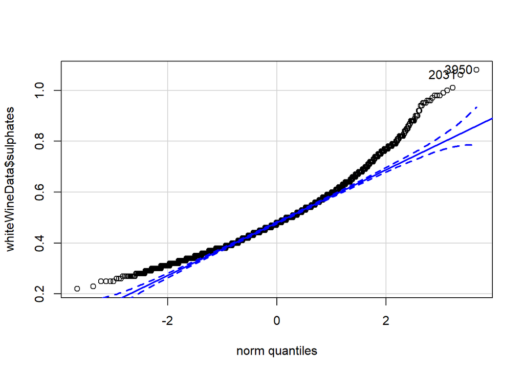

```
## [1] 3950 2031
```

```r
qqPlot(whiteWineData$sulphates)
```

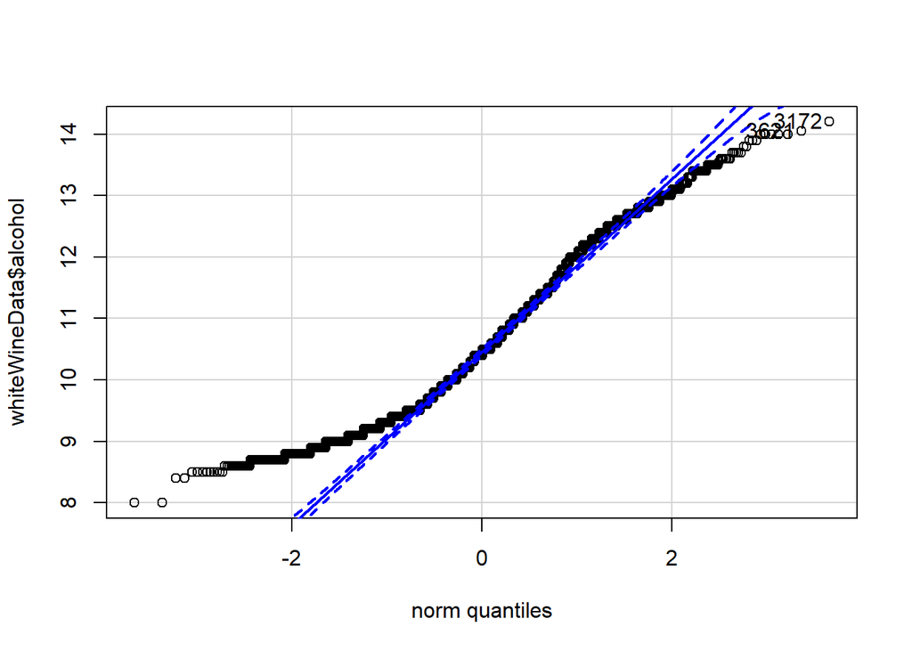

```
## [1] 3172 3621
```

```r
qqPlot(whiteWineData$alcohol)
```

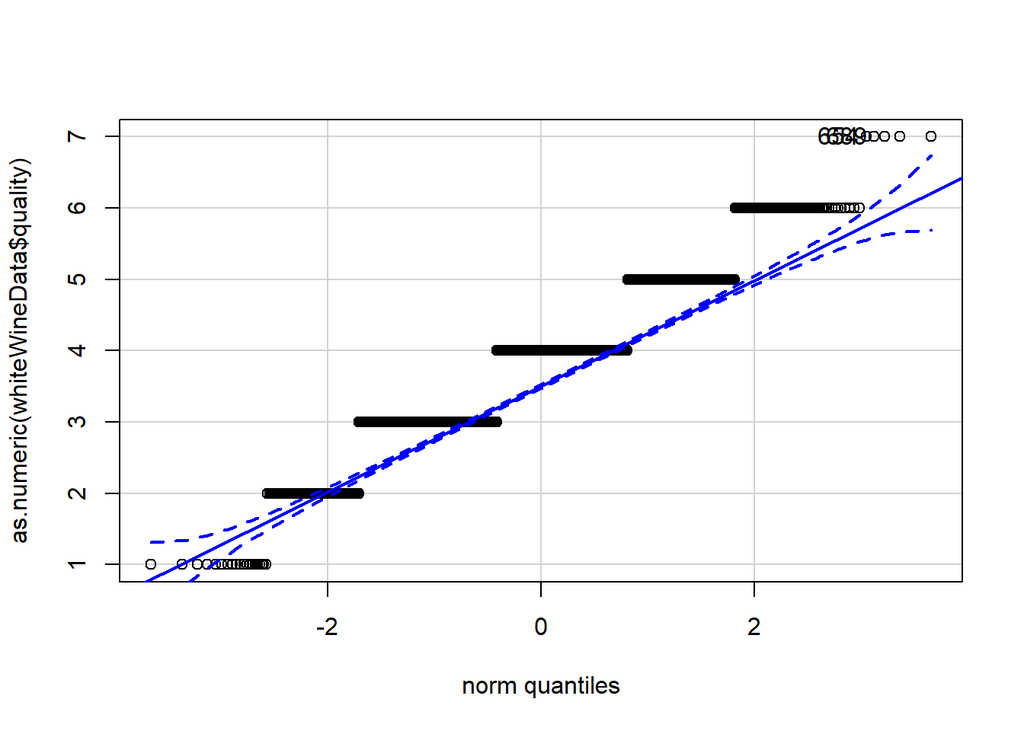

```
## [1] 654 689
```

```r
qqPlot(as.numeric(whiteWineData$quality))
```

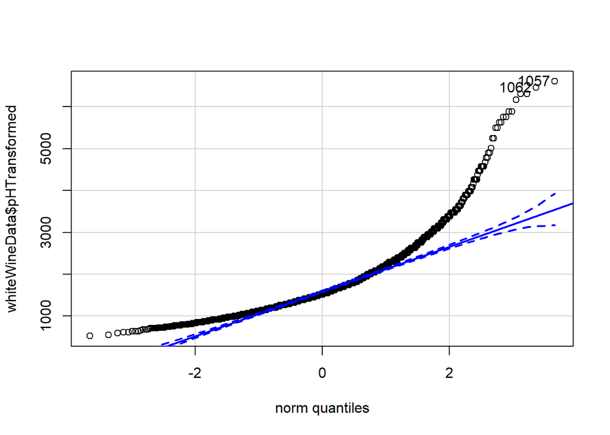

```
## [1] 1057 1062
```

```r
qqPlot(whiteWineData$pHTransformed)
```

The following are not normally distributed * residual sugar (positive skew) * total sulphur dioxide (bimodal) * alcohol

From the QQ plots, most variables are right-skewed and none of them are perfectly normal

## Testing for Correlation

```r
leveneTest(wineData$fixed.acidity, wineData$quality)
```

```
## Levene's Test for Homogeneity of Variance (center = median)
##         Df F value Pr(>F)
## group    6  1.4544 0.1898
##       5313
```

```r
leveneTest(wineData$citric.acid, wineData$quality)
```

```
## Levene's Test for Homogeneity of Variance (center = median)
##         Df F value    Pr(>F)
## group    6  30.194 < 2.2e-16 ***
##       5313
## ---
## Signif. codes:  0 '***' 0.001 '**' 0.01 '*' 0.05 '.' 0.1 ' ' 1
```

```r
leveneTest(wineData$chlorides, wineData$quality)
```

```
## Levene's Test for Homogeneity of Variance (center = median)
##         Df F value    Pr(>F)
## group    6  14.341 2.746e-16 ***
##       5313
## ---
## Signif. codes:  0 '***' 0.001 '**' 0.01 '*' 0.05 '.' 0.1 ' ' 1
```

```r
leveneTest(wineData$sulphates, wineData$quality)
```

```
## Levene's Test for Homogeneity of Variance (center = median)
##         Df F value    Pr(>F)
## group    6  11.539 7.161e-13 ***
##       5313
## ---
## Signif. codes:  0 '***' 0.001 '**' 0.01 '*' 0.05 '.' 0.1 ' ' 1
```

```r
leveneTest(wineData$pHTransformed, wineData$quality)
```

```
## Levene's Test for Homogeneity of Variance (center = median)
##         Df F value    Pr(>F)
## group    6  3.8943 0.0006952 ***
##       5313
## ---
## Signif. codes:  0 '***' 0.001 '**' 0.01 '*' 0.05 '.' 0.1 ' ' 1
```

```r
wineDataAsNumeric <- wineData
wineDataAsNumeric$quality <- as.numeric(wineDataAsNumeric$quality)
cor(wineDataAsNumeric, method="kendall")
```

```
##                      fixed.acidity volatile.acidity citric.acid
## fixed.acidity           1.00000000       0.13849183  0.19604674
## volatile.acidity        0.13849183       1.00000000 -0.20781178
## citric.acid             0.19604674      -0.20781178  1.00000000
## residual.sugar         -0.01484950      -0.02349221  0.05162430
## chlorides               0.25050015       0.29405738 -0.04276091
## free.sulfur.dioxide    -0.18264759      -0.25152210  0.08400461
## total.sulfur.dioxide   -0.16402817      -0.22039165  0.11025923
## density                 0.31588479       0.20653259  0.03922389
## sulphates               0.15931794       0.17876277  0.01991133
## alcohol                -0.07676154      -0.03855774  0.01710412
## quality                -0.08057883      -0.19365809  0.09073069
## color                   0.35542732       0.49645118 -0.13045802
## pHTransformed          -0.18099587       0.12421793 -0.21228649
##                      residual.sugar   chlorides free.sulfur.dioxide
## fixed.acidity           -0.01484950  0.25050015         -0.18264759
## volatile.acidity        -0.02349221  0.29405738         -0.25152210
## citric.acid              0.05162430 -0.04276091          0.08400461
## residual.sugar           1.00000000 -0.01631328          0.24795789
## chlorides               -0.01631328  1.00000000         -0.17066891
## free.sulfur.dioxide      0.24795789 -0.17066891          1.00000000
## total.sulfur.dioxide     0.28839066 -0.15917131          0.56026393
## density                  0.35449445  0.43070514         -0.01880386
## sulphates               -0.07831243  0.26405385         -0.16086870
## alcohol                 -0.18187373 -0.28913717         -0.11109464
## quality                 -0.02175691 -0.23575967          0.06900687
## color                   -0.18080398  0.55010266         -0.42539613
## pHTransformed           -0.13559780  0.10934333         -0.11012891
##                      total.sulfur.dioxide     density   sulphates
## fixed.acidity                 -0.16402817  0.31588479  0.15931794
## volatile.acidity              -0.22039165  0.20653259  0.17876277
## citric.acid                    0.11025923  0.03922389  0.01991133
## residual.sugar                 0.28839066  0.35449445 -0.07831243
## chlorides                     -0.15917131  0.43070514  0.26405385
## free.sulfur.dioxide            0.56026393 -0.01880386 -0.16086870
## total.sulfur.dioxide           1.00000000  0.02764396 -0.17019510
## density                        0.02764396  1.00000000  0.20802687
## sulphates                     -0.17019510  0.20802687  1.00000000
## alcohol                       -0.18943916 -0.50625142 -0.00733231
## quality                       -0.04539709 -0.26778895  0.02822772
## color                         -0.55585629  0.37100263  0.41234992
## pHTransformed                 -0.15386333  0.02663180  0.16165749
##                          alcohol     quality       color pHTransformed
## fixed.acidity        -0.07676154 -0.08057883  0.35542732   -0.18099587
## volatile.acidity     -0.03855774 -0.19365809  0.49645118    0.12421793
## citric.acid           0.01710412  0.09073069 -0.13045802   -0.21228649
## residual.sugar       -0.18187373 -0.02175691 -0.18080398   -0.13559780
## chlorides            -0.28913717 -0.23575967  0.55010266    0.10934333
## free.sulfur.dioxide  -0.11109464  0.06900687 -0.42539613   -0.11012891
## total.sulfur.dioxide -0.18943916 -0.04539709 -0.55585629   -0.15386333
## density              -0.50625142 -0.26778895  0.37100263    0.02663180
## sulphates            -0.00733231  0.02822772  0.41234992    0.16165749
## alcohol               1.00000000  0.37774081 -0.04141902    0.07631408
## quality               0.37774081  1.00000000 -0.11193173    0.04088314
## color                -0.04141902 -0.11193173  1.00000000    0.26278257
## pHTransformed         0.07631408  0.04088314  0.26278257    1.00000000
```

## Hypotheses

### 1. What factors impact wine quality? Hypothesis: Low acidity and sugar content are major indicators of wine quality.

#### 1.1 Linear Regression

##### Assumptions for Linear Regression

1. All predictor variables must be quantitative or categorical, and outcome must be quantitative, continuous, and unbounded (Y)
2. Non-zero variance (Y)
3. No perfect multicollinearity (predictor variables should not correlate highly)
4. Predictors are uncorrelated with external variables (Y - we have to assume)
5. Residuals are homoscedastic (constant variance), independent (test with Durbin-Watson), Normal
6. Linearity (outcome variable means lie on straight line)

First, we perform linear regression off twelve variables to predict the outcome variable: quality. By running the lm command, we receive co-efficient estimates, standard error, t-value and p-values.

```r
wineQuality.model <- lm(as.numeric(quality) ~ fixed.acidity + volatile.acidity + citric.acid + residual.sugar + chlorides + free.sulfur.dioxide + total.sulfur.dioxide + density + pHTransformed + sulphates + alcohol + color, data=wineData)
summary(wineQuality.model)
```

```
##
## Call:
## lm(formula = as.numeric(quality) ~ fixed.acidity + volatile.acidity +
##     citric.acid + residual.sugar + chlorides + free.sulfur.dioxide +
##     total.sulfur.dioxide + density + pHTransformed + sulphates +
##     alcohol + color, data = wineData)
##
## Residuals:
##     Min      1Q  Median      3Q     Max
## -3.9607 -0.4541 -0.0348  0.4668  3.1404
##
## Coefficients:
##                        Estimate Std. Error t value Pr(>|t|)
## (Intercept)           7.117e+01  1.485e+01   4.794 1.68e-06 ***
## fixed.acidity         4.163e-02  1.638e-02   2.541 0.011071 *
## volatile.acidity     -1.372e+00  8.802e-02 -15.584  < 2e-16 ***
## citric.acid           1.005e-01  8.809e-02   1.141 0.253940
## residual.sugar        4.242e-02  6.255e-03   6.781 1.32e-11 ***
## chlorides            -1.110e+00  3.494e-01  -3.178 0.001489 **
## free.sulfur.dioxide   5.958e-03  8.460e-04   7.043 2.13e-12 ***
## total.sulfur.dioxide -1.566e-03  3.555e-04  -4.405 1.08e-05 ***
## density              -7.112e+01  1.492e+01  -4.767 1.92e-06 ***
## pHTransformed         6.934e-05  1.989e-05   3.487 0.000493 ***
## sulphates             7.236e-01  8.385e-02   8.630  < 2e-16 ***
## alcohol               2.616e-01  1.914e-02  13.663  < 2e-16 ***
## color                 3.090e-01  6.093e-02   5.071 4.10e-07 ***
## ---
## Signif. codes:  0 '***' 0.001 '**' 0.01 '*' 0.05 '.' 0.1 ' ' 1
##
## Residual standard error: 0.7328 on 5307 degrees of freedom
## Multiple R-squared:  0.3077, Adjusted R-squared:  0.3061
## F-statistic: 196.6 on 12 and 5307 DF,  p-value: < 2.2e-16
```

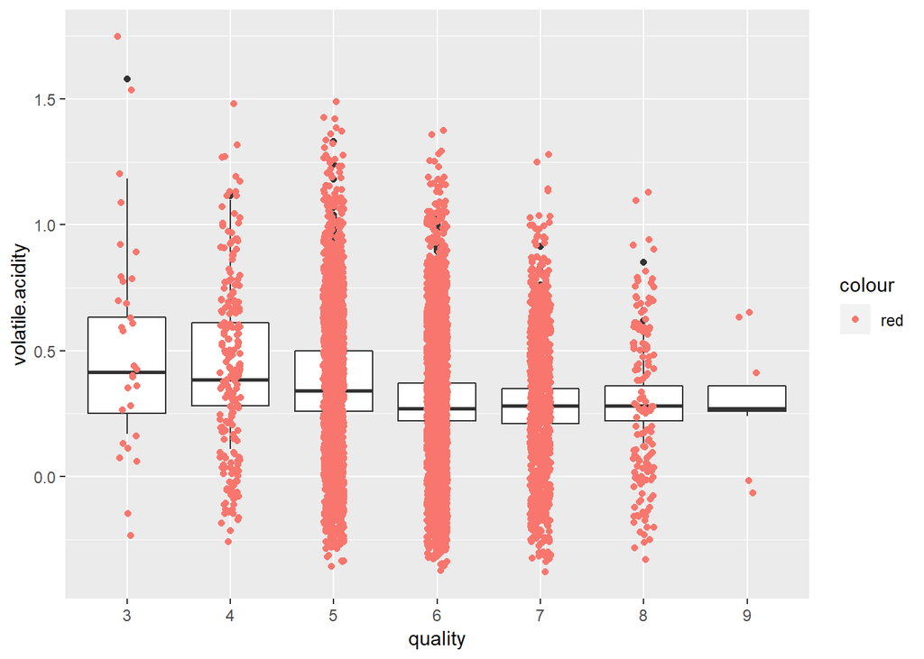

```r
ggplot(data=wineData, aes(x=quality, y=volatile.acidity, group=quality)) +
  geom_boxplot() +
  geom_jitter(width=0.1, height=0.5, aes(color="red"))
```

It seems that highly acidic wines tend to be of lower quality, though there is significant variance.

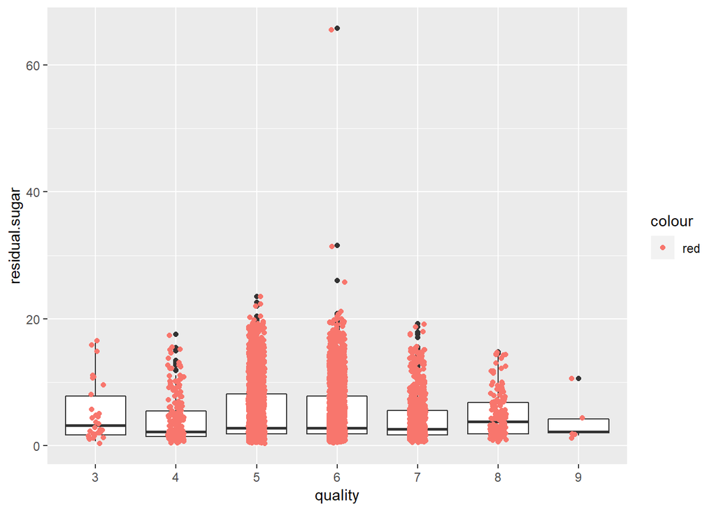

```r
ggplot(data=wineData, aes(x=quality, y=residual.sugar, group=quality)) +
  geom_boxplot() +
  geom_jitter(width=0.1, height=0.5, aes(color="red"))
```

By itself, residual sugar level does not seem to be correlated with the quality of the wine.

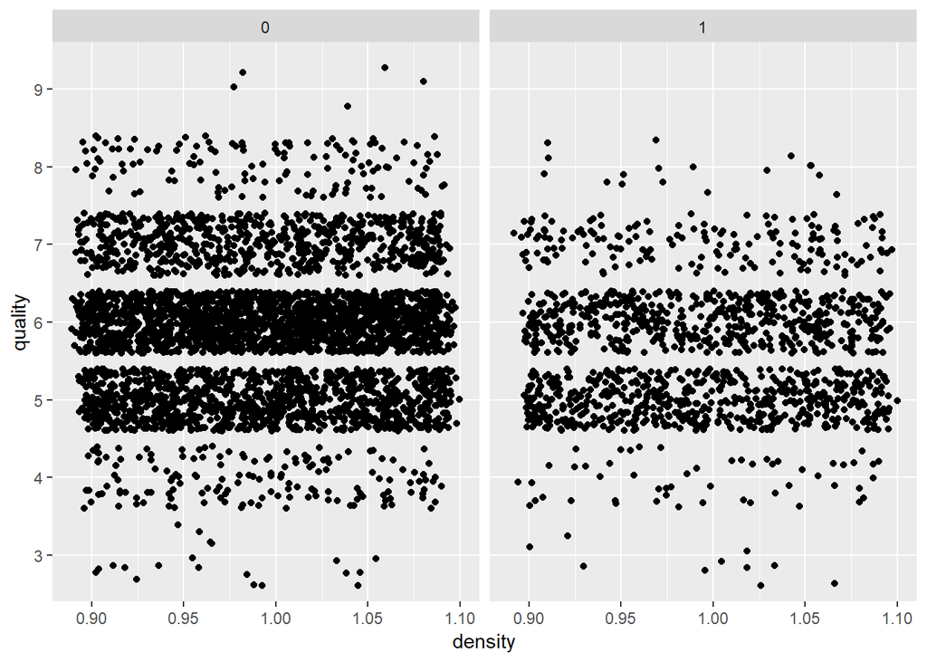

```r
ggplot(wineData, aes(y=quality, x=density)) + geom_jitter(width=0.1) + facet_grid(~color)
```

### 2. What factors predict wine colour? Hypothesis: Acidity is a strong predictor of wine colour (i.e. red vs. white)

#### 2.1 Linear Regression

```r
# Note, the parameters provided do not include quality since this is a subjective measure.
wineColor.modelFull <- lm(color ~ fixed.acidity + volatile.acidity + citric.acid + residual.sugar + chlorides + free.sulfur.dioxide + total.sulfur.dioxide + density + pHTransformed + sulphates + alcohol, data=wineData)
summary(wineColor.modelFull)
```

```
##
## Call:
## lm(formula = color ~ fixed.acidity + volatile.acidity + citric.acid +
##     residual.sugar + chlorides + free.sulfur.dioxide + total.sulfur.dioxide +
##     density + pHTransformed + sulphates + alcohol, data = wineData)
##
## Residuals:
##     Min      1Q  Median      3Q     Max
## -3.2182 -0.0939 -0.0046  0.0864  1.4728
##
## Coefficients:
##                        Estimate Std. Error t value Pr(>|t|)
## (Intercept)          -1.329e+02  2.803e+00 -47.409  < 2e-16 ***
## fixed.acidity        -4.482e-02  3.638e-03 -12.317  < 2e-16 ***
## volatile.acidity      4.642e-01  1.878e-02  24.723  < 2e-16 ***
## citric.acid          -1.184e-01  1.978e-02  -5.989 2.26e-09 ***
## residual.sugar       -5.159e-02  1.218e-03 -42.345  < 2e-16 ***
## chlorides             6.877e-01  7.813e-02   8.802  < 2e-16 ***
## free.sulfur.dioxide   3.087e-03  1.858e-04  16.614  < 2e-16 ***
## total.sulfur.dioxide -3.049e-03  6.827e-05 -44.657  < 2e-16 ***
## density               1.333e+02  2.819e+00  47.269  < 2e-16 ***
## pHTransformed        -3.121e-05  4.459e-06  -6.999 2.89e-12 ***
## sulphates             1.479e-01  1.878e-02   7.879 3.98e-15 ***
## alcohol               1.203e-01  3.984e-03  30.200  < 2e-16 ***
## ---
## Signif. codes:  0 '***' 0.001 '**' 0.01 '*' 0.05 '.' 0.1 ' ' 1
##
## Residual standard error: 0.1651 on 5308 degrees of freedom
## Multiple R-squared:  0.857,  Adjusted R-squared:  0.8567
## F-statistic:  2893 on 11 and 5308 DF,  p-value: < 2.2e-16
```

All variables are considered significant in determining the colour of the wine; p-value < 2e-16 for most variables.

However, if we wanted to reduce the number of variables required to make a good prediction, we can remove some with the lowest abs(t-value) and still have an R-squared around 0.85.

```r
# Removed variables with low t-values
wineColor.modelReduced <- lm(color ~ fixed.acidity + volatile.acidity + residual.sugar + chlorides + total.sulfur.dioxide + density + alcohol, data=wineData)
summary(wineColor.modelReduced)
```

```
##
## Call:
## lm(formula = color ~ fixed.acidity + volatile.acidity + residual.sugar +
##     chlorides + total.sulfur.dioxide + density + alcohol, data = wineData)
##
## Residuals:
##     Min      1Q  Median      3Q     Max
## -3.3278 -0.0961 -0.0027  0.0923  1.3644
##
## Coefficients:
##                        Estimate Std. Error t value Pr(>|t|)
## (Intercept)          -1.295e+02  2.102e+00  -61.62   <2e-16 ***
## fixed.acidity        -4.044e-02  2.622e-03  -15.42   <2e-16 ***
## volatile.acidity      4.669e-01  1.756e-02   26.60   <2e-16 ***
## residual.sugar       -4.943e-02  9.599e-04  -51.49   <2e-16 ***
## chlorides             9.050e-01  7.616e-02   11.88   <2e-16 ***
## total.sulfur.dioxide -2.458e-03  5.722e-05  -42.96   <2e-16 ***
## density               1.299e+02  2.105e+00   61.69   <2e-16 ***
## alcohol               1.164e-01  3.347e-03   34.77   <2e-16 ***
## ---
## Signif. codes:  0 '***' 0.001 '**' 0.01 '*' 0.05 '.' 0.1 ' ' 1
##
## Residual standard error: 0.1715 on 5312 degrees of freedom
## Multiple R-squared:  0.8456, Adjusted R-squared:  0.8454
## F-statistic:  4156 on 7 and 5312 DF,  p-value: < 2.2e-16
```

This model uses 7 variables instead of 11 and only has an R-squared value that’s ~0.01 lower. This may be “good enough” of a predictor that conveniently requires less variables to input.

#### 2.2 Logistic Regression

```r
#Lets use Logistic Regression to try and predict wine colour!

# We'll want to use some train-test split on the data to validate our logistic regression model.
wineDataShuffled <- wineData[sample(nrow(wineData)),]
wineLength <- nrow(wineDataShuffled)  # 6497
wineLengthEightyP <- as.integer(nrow(wineDataShuffled)*0.8)  # 5197
#create train and test set; 60%-40% split
train = wineDataShuffled[1:5197,]
test = wineDataShuffled[5198:6497,]

# Lets check out a bunch of feature variables
glm.fit1 = glm(color ~ pHTransformed + volatile.acidity + chlorides + total.sulfur.dioxide, data = train, family = binomial)
summary(glm.fit1)
```

```
##
## Call:
## glm(formula = color ~ pHTransformed + volatile.acidity + chlorides +
##     total.sulfur.dioxide, family = binomial, data = train)
##
## Deviance Residuals:
##     Min       1Q   Median       3Q      Max
## -3.4766  -0.1180  -0.0381   0.0011   5.6227
##
## Coefficients:
##                        Estimate Std. Error z value Pr(>|z|)
## (Intercept)          -4.1236393  0.3753386 -10.986   <2e-16 ***
## pHTransformed         0.0009889  0.0001097   9.018   <2e-16 ***
## volatile.acidity     10.2709198  0.6152269  16.695   <2e-16 ***
## chlorides            44.1233506  2.5641524  17.208   <2e-16 ***
## total.sulfur.dioxide -0.0622264  0.0025718 -24.195   <2e-16 ***
## ---
## Signif. codes:  0 '***' 0.001 '**' 0.01 '*' 0.05 '.' 0.1 ' ' 1
##
## (Dispersion parameter for binomial family taken to be 1)
##
##     Null deviance: 5903.0  on 5196  degrees of freedom
## Residual deviance: 1041.6  on 5192  degrees of freedom
## AIC: 1051.6
##
## Number of Fisher Scoring iterations: 8
```

```r
# Interestingly, all of these variables are shown to be significant, as their p-values are close to 0
# This is a good sign that our model could be a good predictor.
glmProbTrain = predict(glm.fit1, newdata = train, type = "response")
# Use these probabilities to predict red vs wine
glmPredictTrain = ifelse(glmProbTrain > 0.5, "red", "white")
# Lets use a confusion matrix to see how the logistic regression model performed
trainOutcomeValues = cbind(train$color)
trainOutcomeValues = ifelse(trainOutcomeValues == 1, "red", "white")
# Lets see our confusion matrix and accuracy values
confMatTrain <- table(glmPredictTrain, trainOutcomeValues)
# Accuracy:
mean(glmPredictTrain == trainOutcomeValues)
```

```
## [1] 0.9682509
```

```r
# Now let's compare this to our test data
glmProbTest = predict(glm.fit1, newdata = test, type = "response")
# Use these probabilities to predict red vs wine
glmPredictTest = ifelse(glmProbTest > 0.5, "red", "white")
# Lets use a confusion matrix to see how the logistic regression model performed
testOutcomeValues = cbind(test$color)
testOutcomeValues = ifelse(testOutcomeValues == 1, "red", "white")
# Lets see our confusion matrix and accuracy values
confMat <- table(glmPredictTest, testOutcomeValues)
# Accuracy:
mean(glmPredictTest == testOutcomeValues)
```

```
## [1] NA
```

##### Assumptions for Logistic Regression

1. Linearity: linear relationship between continuous predictors and the logit of the outcome variable (see section 8.8.1)
2. Independence of errors: same as linear regression
3. Multicollinearity: same as linear regression plus, there are some unique problems of its own:
4. Incomplete information: need full combinations of variables
5. Complete separation: logistic regression fails if your data does not overlap

### 3. Which wine is better quality: red or white? Hypothesis: Red wine is of higher quality.

##### t-test Assumptions

1. Sampling distribution is normally distributed –> based on visual inspection, quality appears to be relatively normally distributed Can’t use stat_desc because there are too many datapoints
2. Data are at least interval (Yes, when not-factored)

```r
t.test(as.numeric(redWineData$quality), as.numeric(whiteWineData$quality))
```

```
##
##  Welch Two Sample t-test
##
## data:  as.numeric(redWineData$quality) and as.numeric(whiteWineData$quality)
## t = -8.7568, df = 2527, p-value < 2.2e-16
## alternative hypothesis: true difference in means is not equal to 0
## 95 percent confidence interval:
##  -0.2834401 -0.1797244
## sample estimates:
## mean of x mean of y
##  3.623252  3.854835
```

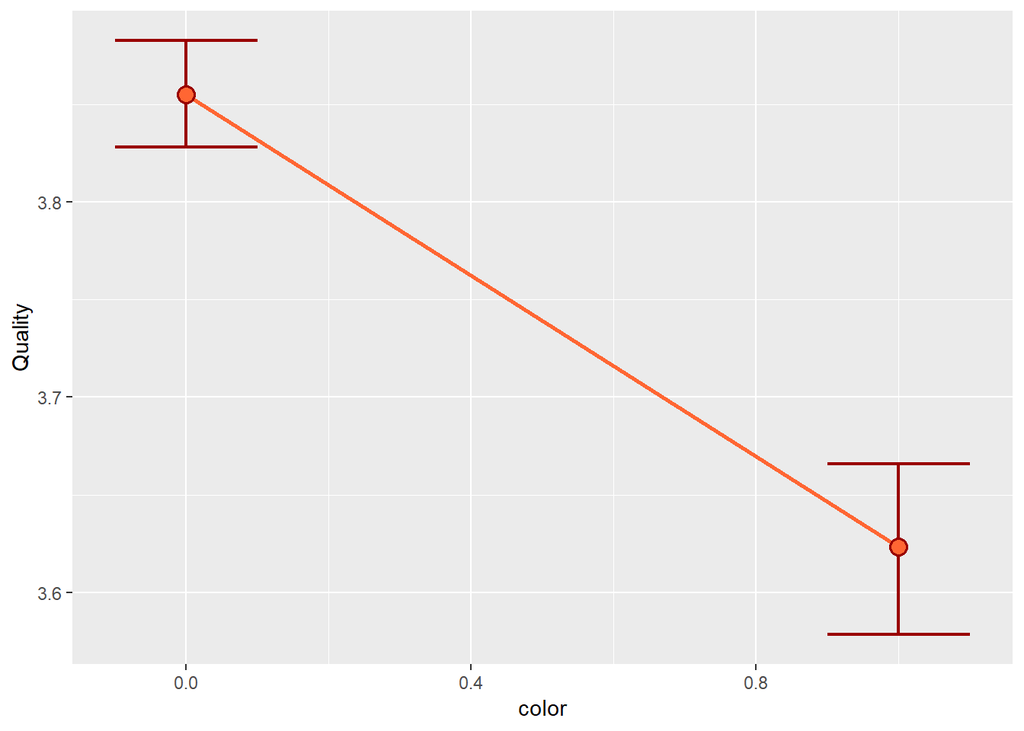

```r
line <- ggplot(wineData, aes(color, as.numeric(quality)))
line + stat_summary(fun.y = mean, geom = "line", size = 1, aes(group=1), colour = "#FF6633") + stat_summary(fun.data = mean_cl_boot, geom = "errorbar", width = 0.2, size = 0.75, colour = "#990000") + stat_summary(fun.y = mean, geom = "point", size = 4, colour = "#990000") + stat_summary(fun.y = mean, geom = "point", size = 3, colour = "#FF6633") + labs(x = "color", y = "Quality")
```

### Assumptions for Logistic Regression

1.linearity: linear relationship between continuous predictors and the logit of the outcome variable (see section 8.8.1) 2.independence of errors: same as linear regression 3.multicollinearity: same as linear regression plus, there are some unique problems of its own: 1.incomplete information: need full combinations of variables 2.complete separation: logistic regression fails if your data does not overlap

### 4.ANOVA

We would like to look if alcohol differs among quality types. We use one-way ANOVA this time.

```r
whiteWineAovModel<-aov(alcohol~as.numeric(quality), data = whiteWineData)
summary(whiteWineAovModel)
```

```
##                       Df Sum Sq Mean Sq F value Pr(>F)
## as.numeric(quality)    1   1257  1256.7    1079 <2e-16 ***
## Residuals           3959   4609     1.2
## ---
## Signif. codes:  0 '***' 0.001 '**' 0.01 '*' 0.05 '.' 0.1 ' ' 1
```

```r
redWineAovModel<-aov(alcohol~quality, data = redWineData)
summary(redWineAovModel)
```

```
##               Df Sum Sq Mean Sq F value Pr(>F)
## quality        5  439.7   87.94   103.4 <2e-16 ***
## Residuals   1353 1150.3    0.85
## ---
## Signif. codes:  0 '***' 0.001 '**' 0.01 '*' 0.05 '.' 0.1 ' ' 1
```

The result of the one-way ANOVA show significant difference in alcohol content among quality types for both white wine and red wine. This is clear by the high F-statistic and small p-value.

```r
smallerWhiteWine <- whiteWineData[1:1359,]
smallerWhiteWineAovModel<-aov(alcohol~quality, data = smallerWhiteWine)
summary(smallerWhiteWineAovModel)
```

```
##               Df Sum Sq Mean Sq F value Pr(>F)
## quality        6  421.2   70.20   74.88 <2e-16 ***
## Residuals   1352 1267.6    0.94
## ---
## Signif. codes:  0 '***' 0.001 '**' 0.01 '*' 0.05 '.' 0.1 ' ' 1
```

The p-value is still significant while the F value is now smaller than red wine.